# Real Estate Price Prediction

### Step 3: Model Building

#### Lets build linear regression model on train_75 dataset.

```r
library(car)
LRf=lm(Price ~ .,data=train_75)
summary(LRf)
```

```
##
## Call:
## lm(formula = Price ~ ., data = train_75)
##
## Residuals:
##      Min       1Q   Median       3Q      Max
## -1662340  -193462   -21807   150940  3847200
##
## Coefficients:
##                  Estimate Std. Error t value Pr(>|t|)
## (Intercept)     6.372e+05  7.479e+05   0.852 0.394246
## Rooms           2.256e+05  9.758e+03  23.116  < 2e-16 ***
## Distance       -3.843e+04  2.660e+03 -14.445  < 2e-16 ***
## Postcode        1.346e+03  2.005e+02   6.714 2.08e-11 ***
## Bedroom2       -4.562e+04  1.113e+04  -4.099 4.21e-05 ***
## Bathroom        1.585e+05  1.065e+04  14.878  < 2e-16 ***
## Car             6.976e+04  7.054e+03   9.890  < 2e-16 ***
## Landsize        7.163e+00  3.886e+00   1.843 0.065310 .
## BuildingArea    4.549e+02  6.187e+01   7.352 2.24e-13 ***
## YearBuilt      -1.719e+03  2.087e+02  -8.235  < 2e-16 ***
## sub_1          -1.088e+06  1.607e+05  -6.769 1.43e-11 ***
## sub_2          -1.026e+06  9.489e+04 -10.809  < 2e-16 ***
## sub_3          -9.449e+05  8.868e+04 -10.656  < 2e-16 ***
## sub_4          -9.259e+05  8.855e+04 -10.456  < 2e-16 ***
## sub_5          -8.619e+05  8.791e+04  -9.804  < 2e-16 ***
## sub_6          -8.078e+05  8.786e+04  -9.194  < 2e-16 ***
## sub_7          -7.538e+05  8.713e+04  -8.651  < 2e-16 ***
## sub_8          -7.713e+05  8.672e+04  -8.893  < 2e-16 ***
## sub_9          -6.876e+05  8.906e+04  -7.720 1.37e-14 ***
## sub_10         -5.407e+05  1.026e+05  -5.268 1.43e-07 ***
## sub_11         -4.600e+05  8.803e+04  -5.226 1.80e-07 ***
## sub_12         -4.807e+05  8.764e+04  -5.485 4.33e-08 ***
## sub_13         -3.529e+05  9.646e+04  -3.658 0.000256 ***
## sub_14         -3.220e+05  8.600e+04  -3.744 0.000183 ***
## sub_15         -4.508e+04  9.946e+04  -0.453 0.650437
## sub_16         -1.503e+05  9.067e+04  -1.658 0.097411 .
## Type_t         -2.415e+05  1.770e+04 -13.645  < 2e-16 ***
## type_u         -4.015e+05  1.515e+04 -26.509  < 2e-16 ***
## Method_PI      -1.191e+05  1.537e+04  -7.746 1.12e-14 ***
## Method_SA      -5.995e+04  8.179e+04  -0.733 0.463596
```

[output cut: 47 more lines]

```
## CA_Kingston    -1.910e+05  6.450e+04  -2.961 0.003084 **
## CA_Hume        -9.056e+04  1.809e+05  -0.501 0.616592
## CA_HobsonsB    -6.407e+04  3.956e+04  -1.619 0.105404
## CA_MoonValley  -5.413e+04  2.719e+04  -1.991 0.046514 *
## CA_Moreland    -1.158e+05  2.443e+04  -4.739 2.20e-06 ***
## CA_PortP       -9.684e+04  3.581e+04  -2.705 0.006860 **
## CA_Stonnington -6.407e+04  2.982e+04  -2.149 0.031700 *
## CA_Whitehorse  -2.575e+04  4.507e+04  -0.571 0.567739
## CA_Yarra       -1.164e+05  3.162e+04  -3.680 0.000236 ***
## ---
## Signif. codes:  0 '***' 0.001 '**' 0.01 '*' 0.05 '.' 0.1 ' ' 1
##
## Residual standard error: 370000 on 5566 degrees of freedom
## Multiple R-squared:  0.6914, Adjusted R-squared:  0.6866
## F-statistic: 146.7 on 85 and 5566 DF,  p-value: < 2.2e-16
```

In order to take care of multi collinearity,we remove variables whose VIF>5,as follows:

```r
a=vif(LRf)
sort(a,decreasing = T)[1:3]
```

```
##    sub_3    sub_7    sub_8
## 36.00506 35.58604 32.98879
```

Removing variable sub_3,Postcode

```r
LRf=lm(Price ~ .-Postcode-sub_3,data=train_75)
summary(LRf)
```

```
##
## Call:
## lm(formula = Price ~ . - Postcode - sub_3, data = train_75)
##
## Residuals:
##      Min       1Q   Median       3Q      Max
## -1674852  -198669   -26909   150628  3836158
##
## Coefficients:
##                  Estimate Std. Error t value Pr(>|t|)
## (Intercept)     3.866e+06  4.137e+05   9.345  < 2e-16 ***
## Rooms           2.277e+05  9.893e+03  23.013  < 2e-16 ***
## Distance       -3.406e+04  2.593e+03 -13.133  < 2e-16 ***
## Bedroom2       -4.694e+04  1.129e+04  -4.156 3.29e-05 ***
## Bathroom        1.564e+05  1.082e+04  14.458  < 2e-16 ***
## Car             7.201e+04  7.163e+03  10.053  < 2e-16 ***
## Landsize        6.351e+00  3.946e+00   1.609 0.107598
## BuildingArea    4.603e+02  6.284e+01   7.326 2.72e-13 ***
## YearBuilt      -1.742e+03  2.120e+02  -8.217 2.57e-16 ***
## sub_1          -2.075e+05  1.374e+05  -1.511 0.130859
## sub_2          -1.179e+05  3.799e+04  -3.103 0.001924 **
## sub_4          -6.069e+03  2.328e+04  -0.261 0.794341
## sub_5           8.810e+04  2.245e+04   3.924 8.82e-05 ***
## sub_6           1.423e+05  2.396e+04   5.939 3.05e-09 ***
## sub_7           2.094e+05  2.452e+04   8.541  < 2e-16 ***
## sub_8           1.950e+05  2.572e+04   7.581 3.99e-14 ***
## sub_9           2.950e+05  2.927e+04  10.077  < 2e-16 ***
## sub_10          3.789e+05  5.808e+04   6.524 7.43e-11 ***
## sub_11          4.560e+05  3.622e+04  12.592  < 2e-16 ***
## sub_12          4.518e+05  3.545e+04  12.744  < 2e-16 ***
## sub_13          6.588e+05  4.791e+04  13.749  < 2e-16 ***
## sub_14          5.878e+05  3.265e+04  18.005  < 2e-16 ***
## sub_15          9.648e+05  5.414e+04  17.820  < 2e-16 ***
## sub_16          7.646e+05  4.175e+04  18.315  < 2e-16 ***
## Type_t         -2.417e+05  1.797e+04 -13.448  < 2e-16 ***
## type_u         -3.962e+05  1.536e+04 -25.786  < 2e-16 ***
## Method_PI      -1.226e+05  1.561e+04  -7.852 4.89e-15 ***
## Method_SA      -6.103e+04  8.307e+04  -0.735 0.462539
## Method_SP      -5.110e+04  1.600e+04  -3.194 0.001409 **
## Method_VB      -9.258e+04  1.785e+04  -5.188 2.20e-07 ***
```

[output cut: 45 more lines]

```
## CA_Kingston    -1.064e+05  6.425e+04  -1.655 0.097912 .
## CA_Hume        -1.012e+05  1.837e+05  -0.551 0.581728
## CA_HobsonsB    -1.582e+05  3.810e+04  -4.150 3.37e-05 ***
## CA_MoonValley  -1.191e+05  2.565e+04  -4.644 3.50e-06 ***
## CA_Moreland    -1.515e+05  2.456e+04  -6.169 7.35e-10 ***
## CA_PortP        2.208e+04  3.123e+04   0.707 0.479515
## CA_Stonnington  1.269e+04  2.892e+04   0.439 0.660879
## CA_Whitehorse  -1.870e+04  4.575e+04  -0.409 0.682699
## CA_Yarra       -1.139e+05  3.211e+04  -3.548 0.000392 ***
## ---
## Signif. codes:  0 '***' 0.001 '**' 0.01 '*' 0.05 '.' 0.1 ' ' 1
##
## Residual standard error: 375800 on 5568 degrees of freedom
## Multiple R-squared:  0.6815, Adjusted R-squared:  0.6767
## F-statistic: 143.5 on 83 and 5568 DF,  p-value: < 2.2e-16
```

```r
a=vif(LRf)
sort(a,decreasing = T)[1:3]
```

```
## Bedroom2    Rooms Distance
## 3.770476 3.705437 3.549597
```

```r
summary(LRf)
```

```
##
## Call:
## lm(formula = Price ~ . - Postcode - sub_3, data = train_75)
##
## Residuals:
##      Min       1Q   Median       3Q      Max
## -1674852  -198669   -26909   150628  3836158
##
## Coefficients:
##                  Estimate Std. Error t value Pr(>|t|)
## (Intercept)     3.866e+06  4.137e+05   9.345  < 2e-16 ***
## Rooms           2.277e+05  9.893e+03  23.013  < 2e-16 ***
## Distance       -3.406e+04  2.593e+03 -13.133  < 2e-16 ***
## Bedroom2       -4.694e+04  1.129e+04  -4.156 3.29e-05 ***
## Bathroom        1.564e+05  1.082e+04  14.458  < 2e-16 ***
## Car             7.201e+04  7.163e+03  10.053  < 2e-16 ***
## Landsize        6.351e+00  3.946e+00   1.609 0.107598
## BuildingArea    4.603e+02  6.284e+01   7.326 2.72e-13 ***
## YearBuilt      -1.742e+03  2.120e+02  -8.217 2.57e-16 ***
## sub_1          -2.075e+05  1.374e+05  -1.511 0.130859
## sub_2          -1.179e+05  3.799e+04  -3.103 0.001924 **
## sub_4          -6.069e+03  2.328e+04  -0.261 0.794341
## sub_5           8.810e+04  2.245e+04   3.924 8.82e-05 ***
## sub_6           1.423e+05  2.396e+04   5.939 3.05e-09 ***
## sub_7           2.094e+05  2.452e+04   8.541  < 2e-16 ***
## sub_8           1.950e+05  2.572e+04   7.581 3.99e-14 ***
## sub_9           2.950e+05  2.927e+04  10.077  < 2e-16 ***
## sub_10          3.789e+05  5.808e+04   6.524 7.43e-11 ***
## sub_11          4.560e+05  3.622e+04  12.592  < 2e-16 ***
## sub_12          4.518e+05  3.545e+04  12.744  < 2e-16 ***
## sub_13          6.588e+05  4.791e+04  13.749  < 2e-16 ***
## sub_14          5.878e+05  3.265e+04  18.005  < 2e-16 ***
## sub_15          9.648e+05  5.414e+04  17.820  < 2e-16 ***
## sub_16          7.646e+05  4.175e+04  18.315  < 2e-16 ***
## Type_t         -2.417e+05  1.797e+04 -13.448  < 2e-16 ***
## type_u         -3.962e+05  1.536e+04 -25.786  < 2e-16 ***
## Method_PI      -1.226e+05  1.561e+04  -7.852 4.89e-15 ***
## Method_SA      -6.103e+04  8.307e+04  -0.735 0.462539
## Method_SP      -5.110e+04  1.600e+04  -3.194 0.001409 **
## Method_VB      -9.258e+04  1.785e+04  -5.188 2.20e-07 ***
```

[output cut: 45 more lines]

```
## CA_Kingston    -1.064e+05  6.425e+04  -1.655 0.097912 .
## CA_Hume        -1.012e+05  1.837e+05  -0.551 0.581728
## CA_HobsonsB    -1.582e+05  3.810e+04  -4.150 3.37e-05 ***
## CA_MoonValley  -1.191e+05  2.565e+04  -4.644 3.50e-06 ***
## CA_Moreland    -1.515e+05  2.456e+04  -6.169 7.35e-10 ***
## CA_PortP        2.208e+04  3.123e+04   0.707 0.479515
## CA_Stonnington  1.269e+04  2.892e+04   0.439 0.660879
## CA_Whitehorse  -1.870e+04  4.575e+04  -0.409 0.682699
## CA_Yarra       -1.139e+05  3.211e+04  -3.548 0.000392 ***
## ---
## Signif. codes:  0 '***' 0.001 '**' 0.01 '*' 0.05 '.' 0.1 ' ' 1
##
## Residual standard error: 375800 on 5568 degrees of freedom
## Multiple R-squared:  0.6815, Adjusted R-squared:  0.6767
## F-statistic: 143.5 on 83 and 5568 DF,  p-value: < 2.2e-16
```

Now removing all variables whose p value is >0.05 one by one.

```r
LRf=lm(Price ~ .-Landsize-GRaine-GMoonee-CA_Bayside-GLITTLE-Gnelson-GSweeney-Ghstuart-CA_Kingston-Gbarry-GRay-GStockdale-GNoel-GJas-GBiggin-GYPA-CA_PortP-CA_Whitehorse-GRendina-GFletchers-GBrad-GHodges-GVillage-GLove-sub_4-GGary-CA_Hume-CA_Boroondara-Method_SA-GWilliams-GHarcourts-GNick-GGreg-CA_Monash-GWoodards-CA_Stonnington-GCayzer-Postcode-sub_3,data=train_75)
summary(LRf)
```

```
##
## Call:
## lm(formula = Price ~ . - Landsize - GRaine - GMoonee - CA_Bayside -
##     GLITTLE - Gnelson - GSweeney - Ghstuart - CA_Kingston - Gbarry -
##     GRay - GStockdale - GNoel - GJas - GBiggin - GYPA - CA_PortP -
##     CA_Whitehorse - GRendina - GFletchers - GBrad - GHodges -
##     GVillage - GLove - sub_4 - GGary - CA_Hume - CA_Boroondara -
##     Method_SA - GWilliams - GHarcourts - GNick - GGreg - CA_Monash -
##     GWoodards - CA_Stonnington - GCayzer - Postcode - sub_3,
##     data = train_75)
##
## Residuals:
##      Min       1Q   Median       3Q      Max
## -1656253  -198103   -26651   152266  3860482
##
## Coefficients:
##                 Estimate Std. Error t value Pr(>|t|)
## (Intercept)    3895526.2   410315.4   9.494  < 2e-16 ***
## Rooms           230453.8     9817.6  23.474  < 2e-16 ***
## Distance        -36543.2     2177.0 -16.786  < 2e-16 ***
## Bedroom2        -49181.9    10962.2  -4.486 7.39e-06 ***
## Bathroom        152338.3     9796.0  15.551  < 2e-16 ***
## Car              71883.3     6932.3  10.369  < 2e-16 ***
## BuildingArea       456.2       62.7   7.276 3.90e-13 ***
## YearBuilt        -1758.6      210.9  -8.339  < 2e-16 ***
## sub_1          -273475.0   105758.2  -2.586  0.00974 **
## sub_2          -112772.3    36858.2  -3.060  0.00223 **
## sub_5            94069.4    19621.4   4.794 1.68e-06 ***
## sub_6           144194.2    19408.8   7.429 1.26e-13 ***
## sub_7           216978.0    20449.8  10.610  < 2e-16 ***
## sub_8           196349.4    21932.0   8.953  < 2e-16 ***
## sub_9           299226.1    27050.0  11.062  < 2e-16 ***
## sub_10          377663.0    55937.6   6.752 1.61e-11 ***
## sub_11          456073.2    31635.9  14.416  < 2e-16 ***
## sub_12          450564.6    31299.9  14.395  < 2e-16 ***
## sub_13          597071.7    34730.8  17.191  < 2e-16 ***
## sub_14          580413.7    27760.1  20.908  < 2e-16 ***
## sub_15          898556.4    40814.8  22.015  < 2e-16 ***
## sub_16          768474.4    38796.4  19.808  < 2e-16 ***
## Type_t         -241570.0    17712.5 -13.638  < 2e-16 ***
```

[output cut: 15 more lines]

```
## CA_Darebin     -121975.2    22895.1  -5.328 1.03e-07 ***
## CA_Glen_Eira     63622.7    24966.5   2.548  0.01085 *
## CA_Melbourne    -66990.4    31641.0  -2.117  0.03429 *
## CA_Maribyrnong -182664.9    26894.4  -6.792 1.22e-11 ***
## CA_Manningham  -116875.2    40860.4  -2.860  0.00425 **
## CA_HobsonsB    -138397.7    33563.2  -4.123 3.79e-05 ***
## CA_MoonValley  -136609.5    21863.4  -6.248 4.45e-10 ***
## CA_Moreland    -167533.8    22109.9  -7.577 4.10e-14 ***
## CA_Yarra       -130267.9    28117.7  -4.633 3.69e-06 ***
## ---
## Signif. codes:  0 '***' 0.001 '**' 0.01 '*' 0.05 '.' 0.1 ' ' 1
##
## Residual standard error: 376000 on 5605 degrees of freedom
## Multiple R-squared:  0.6791, Adjusted R-squared:  0.6764
## F-statistic: 257.8 on 46 and 5605 DF,  p-value: < 2.2e-16
```

#### Thus linear regression model is successfully built.

### Step 4.Perfomance measurement of the model.

#### Lets check the performance of the model on test_25 and calculate RMSE

```r
PP_test_25=predict(LRf,newdata =test_25)
PP_test_25=round(PP_test_25,1)
class(PP_test_25)
```

```
## [1] "numeric"
```

PP_test_25 contains the predicted price values for corresponding observations based on the model LRF. ####Calculating the RMSE and Plotting the graph.

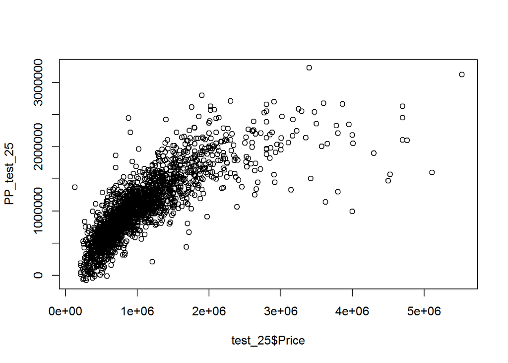

```r
#lets plot the real price vs predicted price for dataset test_25:
plot(test_25$Price,PP_test_25)
```

```r
res=test_25$Price-PP_test_25 #(real value-predicted value)
#root mean square error is as follows
RMSE_test_25=sqrt(mean(res^2))
RMSE_test_25
```

```
## [1] 387505.6
```

```r
#the passing criteria mentioned,was to have value >0.5 which we have successfuly crossed.Hence our model is good.
212467/RMSE_test_25
```

```
## [1] 0.548294
```

#### lets create diagonostic plots for linearity:

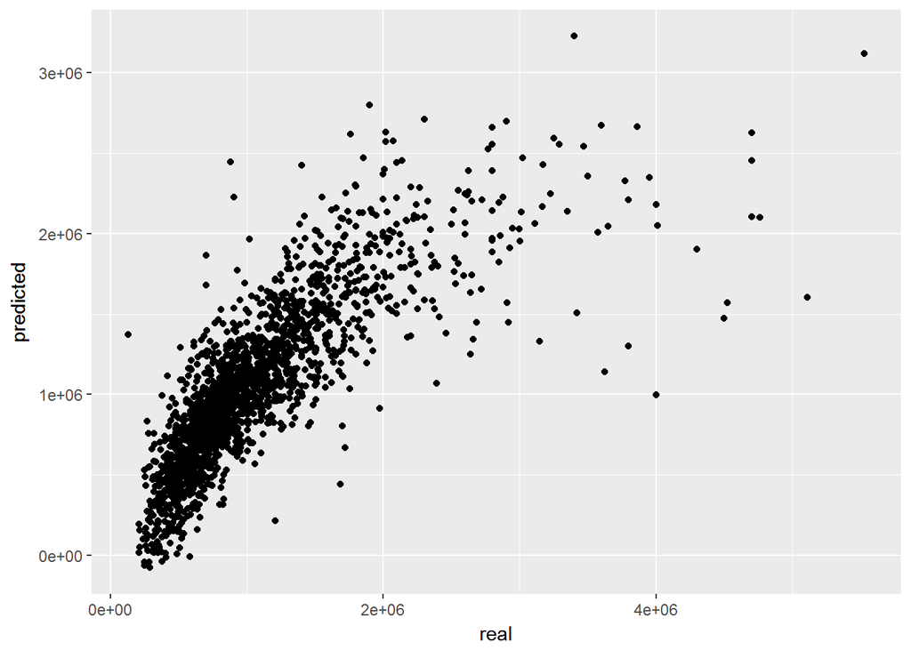

```r
library(ggplot2)
d=data.frame(real=test_25$Price,predicted=PP_test_25)
ggplot(d,aes(x=real,y=predicted))+geom_point()
```

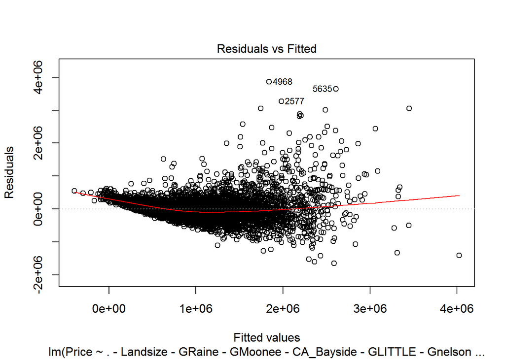

```r
plot(LRf,which = 1) #gives residual vz fitted plot
```

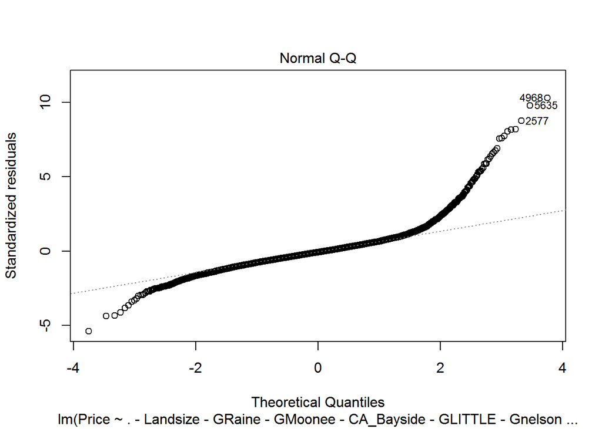

```r
plot(LRf,which = 2) #gives q-q-plot
```

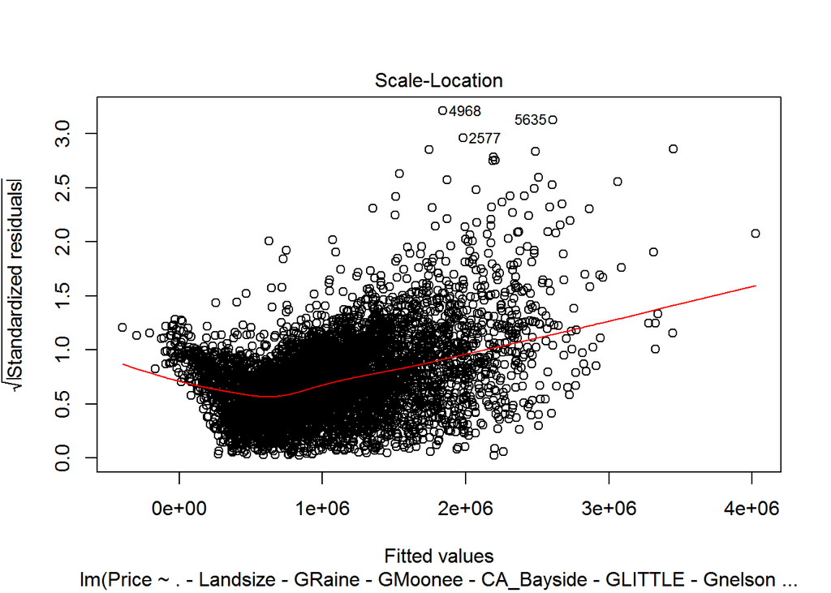

```r
plot(LRf,which = 3) #gives scale-location plot
```

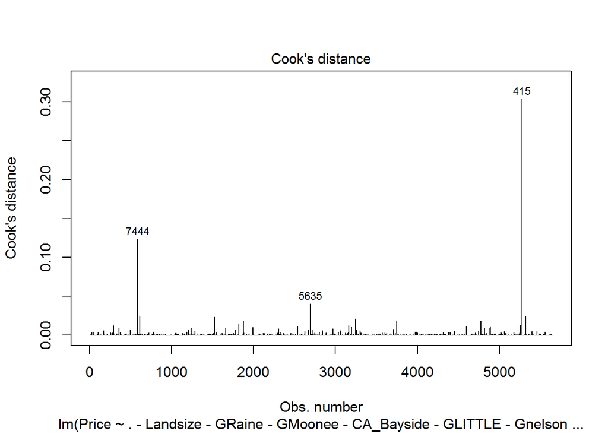

```r
plot(LRf,which = 4) #gives cooks distance
```

### STEP 5:Predicting Real Estate Prices for the final Test Dataset.

#### As per the model thus built,we can now predict Prices for the Test dataset as follows:

```r
PP_test_final=predict(LRf,newdata =test)
PP_test_final=round(PP_test_final,1)
class(PP_test_final)
```

```
## [1] "numeric"
```

```r
write.csv(PP_test_final, "PP_test_final.csv")#stores the predicted prices in a csv file on your local repository in pc.
```

```r
summary(LRf)
```

```
##
## Call:
## lm(formula = Price ~ . - Landsize - GRaine - GMoonee - CA_Bayside -
##     GLITTLE - Gnelson - GSweeney - Ghstuart - CA_Kingston - Gbarry -
##     GRay - GStockdale - GNoel - GJas - GBiggin - GYPA - CA_PortP -
##     CA_Whitehorse - GRendina - GFletchers - GBrad - GHodges -
##     GVillage - GLove - sub_4 - GGary - CA_Hume - CA_Boroondara -
##     Method_SA - GWilliams - GHarcourts - GNick - GGreg - CA_Monash -
##     GWoodards - CA_Stonnington - GCayzer - Postcode - sub_3,
##     data = train_75)
##
## Residuals:
##      Min       1Q   Median       3Q      Max
## -1656253  -198103   -26651   152266  3860482
##
## Coefficients:
##                 Estimate Std. Error t value Pr(>|t|)
## (Intercept)    3895526.2   410315.4   9.494  < 2e-16 ***
## Rooms           230453.8     9817.6  23.474  < 2e-16 ***
## Distance        -36543.2     2177.0 -16.786  < 2e-16 ***
## Bedroom2        -49181.9    10962.2  -4.486 7.39e-06 ***
## Bathroom        152338.3     9796.0  15.551  < 2e-16 ***
## Car              71883.3     6932.3  10.369  < 2e-16 ***
## BuildingArea       456.2       62.7   7.276 3.90e-13 ***
## YearBuilt        -1758.6      210.9  -8.339  < 2e-16 ***
## sub_1          -273475.0   105758.2  -2.586  0.00974 **
## sub_2          -112772.3    36858.2  -3.060  0.00223 **
## sub_5            94069.4    19621.4   4.794 1.68e-06 ***
## sub_6           144194.2    19408.8   7.429 1.26e-13 ***
## sub_7           216978.0    20449.8  10.610  < 2e-16 ***
## sub_8           196349.4    21932.0   8.953  < 2e-16 ***
## sub_9           299226.1    27050.0  11.062  < 2e-16 ***
## sub_10          377663.0    55937.6   6.752 1.61e-11 ***
## sub_11          456073.2    31635.9  14.416  < 2e-16 ***
## sub_12          450564.6    31299.9  14.395  < 2e-16 ***
## sub_13          597071.7    34730.8  17.191  < 2e-16 ***
## sub_14          580413.7    27760.1  20.908  < 2e-16 ***
## sub_15          898556.4    40814.8  22.015  < 2e-16 ***
## sub_16          768474.4    38796.4  19.808  < 2e-16 ***
## Type_t         -241570.0    17712.5 -13.638  < 2e-16 ***
```

[output cut: 15 more lines]

```
## CA_Darebin     -121975.2    22895.1  -5.328 1.03e-07 ***
## CA_Glen_Eira     63622.7    24966.5   2.548  0.01085 *
## CA_Melbourne    -66990.4    31641.0  -2.117  0.03429 *
## CA_Maribyrnong -182664.9    26894.4  -6.792 1.22e-11 ***
## CA_Manningham  -116875.2    40860.4  -2.860  0.00425 **
## CA_HobsonsB    -138397.7    33563.2  -4.123 3.79e-05 ***
## CA_MoonValley  -136609.5    21863.4  -6.248 4.45e-10 ***
## CA_Moreland    -167533.8    22109.9  -7.577 4.10e-14 ***
## CA_Yarra       -130267.9    28117.7  -4.633 3.69e-06 ***
## ---
## Signif. codes:  0 '***' 0.001 '**' 0.01 '*' 0.05 '.' 0.1 ' ' 1
##
## Residual standard error: 376000 on 5605 degrees of freedom
## Multiple R-squared:  0.6791, Adjusted R-squared:  0.6764
## F-statistic: 257.8 on 46 and 5605 DF,  p-value: < 2.2e-16
```

### Conclusion:

#### *Real estate price prediction was done successfully using linear regression model having Adjusted R-square:0.6764.*